[figure not shown]

# TP1: Apprentissage Artificiel avec Numpy, Pandas et Scikit-Learn

# Table of contents

1. Equation Normale
2. Descente de gradient

## Exercice 1: Equation Normal

```python
import numpy as np
import matplotlib.pyplot as plt
%matplotlib inline
```

### 1. Générer les données à l’allure linéaire suivante

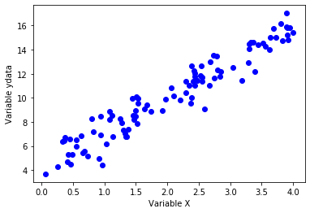

```python
X = 4 * np.random.rand(100, 1)
y = 4 + 3 * X
y_noise = np.random.randn(100, 1)

ydata = y + y_noise

plt.plot(X, ydata,  'bo')
plt.ylabel('Variable ydata')
plt.xlabel('Variable X')
plt.show()
```

### 2. Entraînement du modèle avec Numpy

#### a. Calculer θ à l’aide de l’équation normale.

```python
X_b = np.c_[np.ones((100, 1)), X]  # définir le terme de biais à 1 pour chaque échantillon

%time theta_best = np.linalg.inv(X_b.T.dot(X_b)).dot(X_b.T).dot(ydata)

print(theta_best)
```

```
Wall time: 997 µs
[[4.23794722]
 [2.88698587]]
```

#### b. Les paramètres θ de ce modèle.

```python
print('The coefficient is: ', theta_best[0])
print('The intercept is: ', theta_best[1])
```

[output not shown]

#### c. Interprétation: Pour une valeur de n assez petit et m grand on constate une exécution rapide du modèle d'entrainement.

#### d. Prédictions du modèles.

```python
X_new = np.array([[0], [4]])
X_new_b = np.c_[np.ones((2, 1)), X_new]
y_predict = X_new_b.dot(theta_best)
y_predict
```

```
array([[ 4.23794722],
       [15.78589069]])
```

#### e. Représentation graphique des prédicitions du modèle.

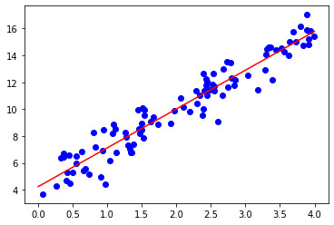

```python
plt.plot(X, ydata, 'bo')
plt.plot(X_new, y_predict, 'r')
plt.show()
```

#### f. Avec des données non linéaires..

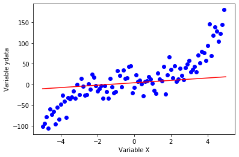

```python
# i. Générer des données non linéaires.
X = np.arange(-5.0, 5.0, 0.1)
y = 1*(X**3) + 1*(X**2) + 1*X + 3
y_noise = 20 * np.random.normal(size=X.size)
ydata = y + y_noise

# Faire une régression linéaire
X_new = np.array([[-5], [5]])
X_new_b = np.c_[np.ones((2, 1)), X_new]
y_predict = X_new_b.dot(theta_best)


# ii. Afficher le résultat sur un graphe.
plt.plot(X, ydata,  'bo')
plt.plot(X_new, y_predict, 'r')
plt.ylabel('Variable ydata')
plt.xlabel('Variable X')
plt.show()
```

```python
# Calculons la fonction cout Mean Squared Error
MSE = np.square(np.subtract(ydata, y_predict)).mean()
print('Mean Squared Error: ', MSE)
```

```
Mean Squared Error:  3288.462005620168
```

#### Interpretation:

Le cout du MSE est bien trop exhaustive (grand) ce qui permet de dire que le modèle trop simpliste pour prédire des données non linéaires. Une solution serait de changer de modèle de sorte à un avoir un qui prédit au mieux les valeurs.

### 3. Entraînement avec la libraire Scikit-Learn.

#### a. Donner le code équivalent de la régression linéaire pour le modèle précédent.

```python
from sklearn.linear_model import LinearRegression

X = 4 * np.random.rand(100, 1)
y = 4 + 3 * X
y_noise = np.random.randn(100, 1)
ydata = y + y_noise

regr = LinearRegression()
regr.fit(X, ydata)

# The coefficients
print ('The coefficient is: ', regr.coef_)
print ('The Intercept is: ', regr.intercept_)
```

```
The coefficient is:  [[3.02761051]]
The Intercept is:  [4.10801815]
```

#### b. Générer un jeu de données non linéaire

```python
X_poly = 8 * np.random.rand(100, 1) - 4
y_poly = 0.5*(X_poly**2) + 1*X_poly + 2
y_noise = np.random.randn(100, 1)
ydata = y_poly + y_noise
```

#### c. Implementer et tester sur des données aléatoires la régression polynomiale

```
(100, 3)
```

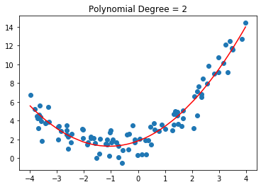

```python
from sklearn.preprocessing import PolynomialFeatures

# perform a polynomial features transform of the dataset
trans = PolynomialFeatures(degree=2)
data = trans.fit_transform(X_poly)
print(data.shape)

regr = LinearRegression()
model = regr.fit(data, ydata)

# prediction
pred = model.predict(data)
X_new, y_new = zip(*sorted(zip(X_poly, pred))) # sort values for plotting

plt.scatter(X_poly, ydata)
plt.plot(X_new, y_new, 'r')
plt.title("Polynomial Degree = 2")
```

#### 4.a Définir une fonction qui trace les courbes d’apprentissage

```python
from sklearn.model_selection import train_test_split
from sklearn.metrics import mean_squared_error

def plot_lcs(model, X, Y, val_split=0.2, metrics=mean_squared_error):
    # train val split
    x_train, x_val, y_train, y_val = train_test_split(X, Y, test_size=val_split)
    # collections of errors:
    train_time_loss, val_time_loss = [], []
    # iterating over train size:
    for train_size in range(1, len(x_train)):
        # training
        model.fit(x_train[:train_size], y_train[:train_size])
        # train and val predictions
        train_preds = model.predict(x_train[:train_size])
        val_preds = model.predict(x_val)
        # metrics calculation
        train_time_loss.append(metrics(y_train[:train_size], train_preds))
        val_time_loss.append(metrics(y_val, val_preds))
    # plotting curves
    plt.plot(np.sqrt(train_time_loss), 'r-*', label='Train loss')
    plt.plot(np.sqrt(val_time_loss), 'b-+', label='Val loss')
    plt.ylabel('RMSE')
    plt.xlabel('Training Set Size')
```

#### 4.b Générer les courbes d’apprentissage pour un modèle de régression linéaire simple et pour un modèle polynomial.

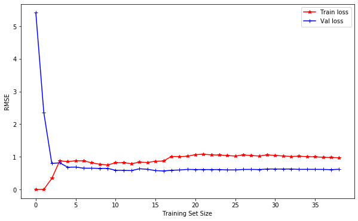

```python
# Pour un modèle de régression linéaire simple
size = 50
###Create X and y array
X = 5 * np.random.rand(size, 1) - 2
y = 4 + 3 * X  + np.random.randn(size, 1)
# instantier le model
model = LinearRegression()

plt.figure(figsize=(10, 6))
plot_lcs(model, X, y)
plt.legend()
plt.show()
```

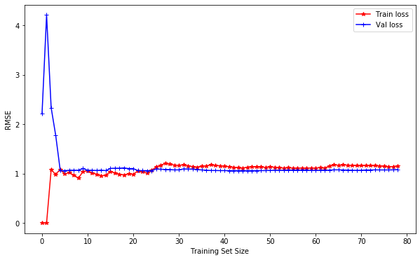

```python
# Pour un modèle de régression polynomial.
size = 100
###Create X and y array
X = 5 * np.random.rand(size, 1) - 2
y = 0.5 * X ** 2 + 1 * X + 2 + np.random.randn(size, 1)

plt.figure(figsize=(10, 6))
plot_lcs(model, X, y)
plt.legend()
plt.show()
```

### 5. Polynomialisation permettant d’éviter le sur-apprentissage.

#### a. Ridge regression

**La régression Ridge** est une extension de la régression linéaire où la fonction de perte est modifiée pour minimiser la complexité du modèle. Cette modification se fait en ajoutant un paramètre de pénalité équivalent au carré de la grandeur des coefficients..

[figure not shown]

```python
# import ridge regression from sklearn library
from sklearn.linear_model import Ridge

#train_test_split
x_train, x_test, y_train, y_test = train_test_split(data, ydata, test_size=0.25)

# Train the model
ridgeR = Ridge(alpha = 1)
ridgeR.fit(x_train, y_train)
y_pred = ridgeR.predict(x_test)

# calculate mean square error
mean_squared_error = np.mean((y_pred - y_test)**2)
print("Mean squared error on test set", mean_squared_error)
```

```
Mean squared error on test set 1.4003796888310331
```

#### b. Lasso regression

**La régression par Lasso** est également une modification de la régression linéaire. Dans Lasso, la fonction de perte est modifiée pour minimiser la complexité du modèle en limitant la somme des valeurs absolues des coefficients du modèle (également appelée norme l1).

[figure not shown]

```python
# import Lasso regression from sklearn library
from sklearn.linear_model import Lasso

# Train the model
lasso = Lasso(alpha = 1)
lasso.fit(x_train, y_train)
y_pred1 = lasso.predict(x_test)

# Calculate Mean Squared Error
mean_squared_error = np.mean((y_pred1 - y_test)**2)
print("Mean squared error on test set", mean_squared_error)
```

```
Mean squared error on test set 16.95441187722254
```

#### c. Elastic Net regression

Parfois, la régression au Lasso peut entraîner un léger biais dans le modèle où la prédiction dépend trop d'une variable particulière. Dans ces cas, **l'Elastic Net** est meilleur, il combine les propriétés de la régression Ridge et Lasso. Cela fonctionne en pénalisant le modèle en utilisant à la fois la norme l2 et la norme l1.

[figure not shown]

```python
# import ElasticNet regression from sklearn library
from sklearn.linear_model import ElasticNet

# Train the model
e_net = ElasticNet(alpha = 1)
e_net.fit(x_train, y_train)

# calculate the prediction and mean square error
y_pred_elastic = e_net.predict(x_test)
mean_squared_error = np.mean((y_pred_elastic - y_test)**2)
print("Mean Squared Error on test set", mean_squared_error)
```

```
Mean Squared Error on test set 17.308282749748383
```

## Exercice 2: Descente de Gradient

### 1. L'mpact de la dimension des pas (taux d’apprentissage) et de la normalisation des données pour la DG.

**Si le taux d’apprentissage (learning rate).**

- est trop petit, l’algorithme doit effectuer un grand nombre d’itérations pour converger et prendra beaucoup de temps ou est coincé dans un miniimum local (vanishing gradient en DL).
- est trop éleve, le risque est de dépasser le point le plus bas et de se retrouver de l’autre cote (exploding gradient en DL).

**Si toutes les variables n’ont pas la meme échelle**, alors la  
convergence sera beaucoup plus lente. Une solution est de  
normaliser les variables d’entrees.

- Si les données sont normalisées, un taux d’apprentissage de 0.01 sera souvent correct (Python). Si l’algorithme met trop de temps à converger, il faudra l’augmenter et si l’algorithme diverge, il faudra le dimunuer.
- Si le nombre d’iterations est trop faible, l’algorithme s’arretera très loin de la solution.
- Si le nombre d’iterations est trop eleve, les paramètres du modèle ne vont plus evoluer.

### 3. Normaliser les données en vous inspirant du script suivant

```python
# Générer des données aléatoires X.
X = 4 * np.random.rand(100, 1)
y = 4 + 3 * X + np.random.randn(100,1)
# Numpy
X_norm =(X-X. mean ( axis =0))/ X. std ( axis =0)
# StandardScaler de ScikitLearn
from sklearn.preprocessing import StandardScaler
scaler = StandardScaler()
X_norm = scaler.fit_transform (X)
```

### 4. Descente de Grandient

#### a. Implémenter l’algorithme de descente de gradient ordinaire

```python
#Fonction pour calculer le cout
def  cal_cost(theta,X,y):
    m = len(y)
    predictions = X.dot(theta)
    cost = (1/2*m) * np.sum(np.square(predictions-y))
    return cost
```

```python
def gradient_descent(X,y,theta,learning_rate=0.01,iterations=1000):
    '''
    Variables:
    X    = Matrice de X with auquel on a ajoute un biais
    y    = Vecteur de Y
    theta= Vector de thetas np.random.randn(j,1)
    learning_rate fixé à 0.01
    iterations = nombre d'iterations

    Retourne au final vecteur theta, le cost history du nombre d'iterations correspondant
    '''
    m = len(y)
    cost_history = np.zeros(iterations)
    theta_history = np.zeros((iterations,2))
    for it in range(iterations):

        prediction = np.dot(X,theta)

        theta = theta -(1/m)*learning_rate*( X.T.dot((prediction - y)))
        theta_history[it,:] =theta.T
        cost_history[it]  = cal_cost(theta,X,y)

    return theta, cost_history, theta_history
```

#### b. Interprétation de l'impact du taux d'apprentissage.

```
Avec un taux d'apprentissage:  0.01
Wall time: 51.9 ms
Theta0: 3.582,
Theta1: 3.214
Final cost/MSE: 5409.306
```

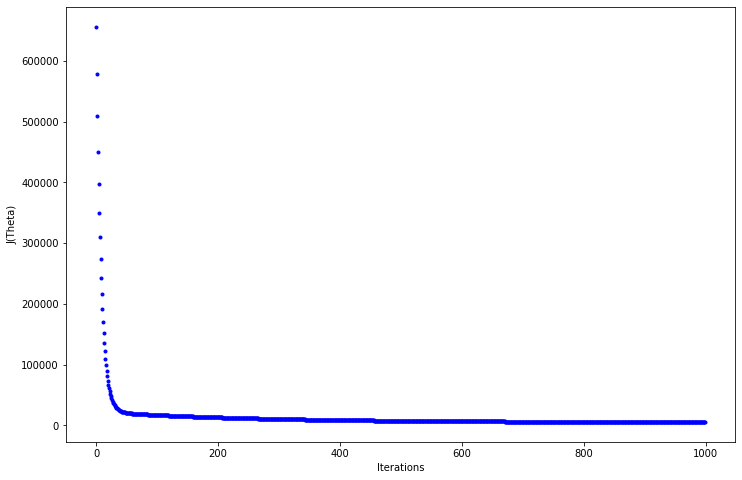

```python
# Taux d'apprentissage = 0.01
lr = 0.01
n_iter = 1000
theta = np.random.randn(2,1)
X_b = np.c_[np.ones((len(X),1)),X]

print("Avec un taux d'apprentissage: ", lr)
%time theta,cost_history,theta_history = gradient_descent(X_b , y, theta, lr, n_iter)

# Affichage du graphe
fig,ax = plt.subplots(figsize=(12,8))
ax.set_ylabel('J(Theta)')
ax.set_xlabel('Iterations')
_=ax.plot(range(n_iter),cost_history,'b.')

print('Theta0: {:0.3f},\nTheta1: {:0.3f}'.format(theta[0][0],theta[1][0]))
print('Final cost/MSE: {:0.3f}\n'.format(cost_history[-1]))
```

```
Avec un taux d'apprentissage:  0.1
Wall time: 47.9 ms
Theta0: 4.106,
Theta1: 3.012
Final cost/MSE: 5091.734
```

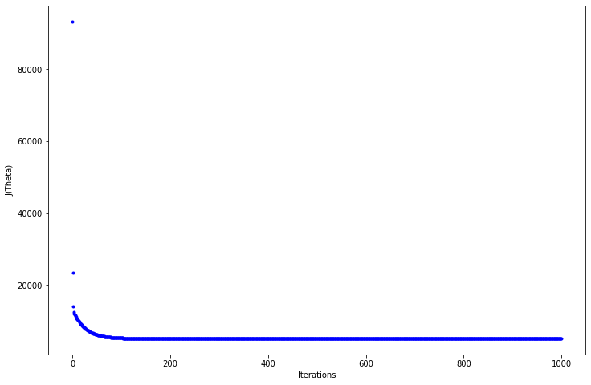

```python
# Taux d'apprentissage = 0.1
lr = 0.1
n_iter = 1000
theta = np.random.randn(2,1)
X_b = np.c_[np.ones((len(X),1)),X]

print("Avec un taux d'apprentissage: ", lr)
%time theta,cost_history,theta_history = gradient_descent(X_b , y, theta, lr, n_iter)

# Affichage du graphe
fig,ax = plt.subplots(figsize=(12,8))
ax.set_ylabel('J(Theta)')
ax.set_xlabel('Iterations')
_=ax.plot(range(n_iter),cost_history,'b.')

print('Theta0: {:0.3f},\nTheta1: {:0.3f}'.format(theta[0][0],theta[1][0]))
print('Final cost/MSE: {:0.3f}\n'.format(cost_history[-1]))
```

```
Avec un taux d'apprentissage:  0.5
Wall time: 49.9 ms
Theta0: nan,
Theta1: nan
Final cost/MSE: nan
```

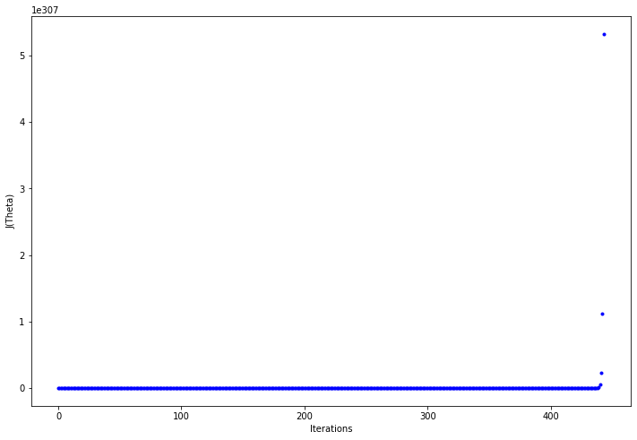

```python
# Taux d'apprentissage = 0.5
lr = 0.5
n_iter = 1000
theta = np.random.randn(2,1)
X_b = np.c_[np.ones((len(X),1)),X]

print("Avec un taux d'apprentissage: ", lr)
%time theta,cost_history,theta_history = gradient_descent(X_b , y, theta, lr, n_iter)

# Affichage du graphe
fig,ax = plt.subplots(figsize=(12,8))
ax.set_ylabel('J(Theta)')
ax.set_xlabel('Iterations')
_=ax.plot(range(n_iter),cost_history,'b.')

print('Theta0: {:0.3f},\nTheta1: {:0.3f}'.format(theta[0][0],theta[1][0]))
print('Final cost/MSE: {:0.3f}\n'.format(cost_history[-1]))
```

#### d. Modification de l'algorithme

```python
def plot_GD(n_iter,lr,ax,ax1=None):
     """
     n_iter = no of iterations
     lr = Learning Rate
     ax = Axis to plot the Gradient Descent
     ax1 = Axis to plot cost_history vs Iterations plot

     """
     _ = ax.plot(X,y,'b.')
     theta = np.random.randn(2,1)

     tr =0.1
     cost_history = np.zeros(n_iter)
     for i in range(n_iter):
        pred_prev = X_b.dot(theta)
        theta,h,_ = gradient_descent(X_b,y,theta,lr,1)
        pred = X_b.dot(theta)

        cost_history[i] = h[0]

        if ((i % 25 == 0) ):
            _ = ax.plot(X,pred,'r-',alpha=tr)
            if tr < 0.8:
                tr = tr+0.2
     if not ax1== None:
        _ = ax1.plot(range(n_iter),cost_history,'b.')
```

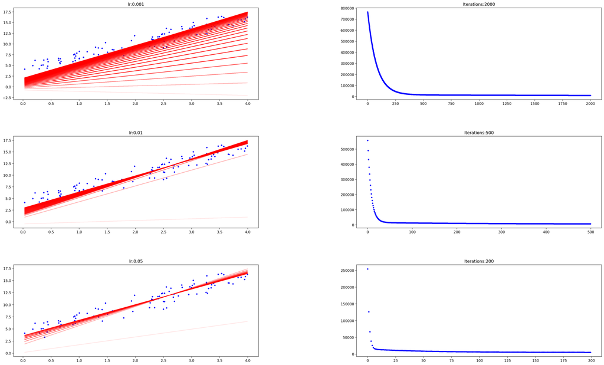

```python
fig = plt.figure(figsize=(30,25),dpi=200)
fig.subplots_adjust(hspace=0.4, wspace=0.4)

it_lr =[(2000,0.001),(500,0.01),(200,0.05)]
count =0
for n_iter, lr in it_lr:
    count += 1

    ax = fig.add_subplot(4, 2, count)
    count += 1

    ax1 = fig.add_subplot(4,2,count)

    ax.set_title("lr:{}".format(lr))
    ax1.set_title("Iterations:{}".format(n_iter))
    plot_GD(n_iter,lr,ax,ax1)
```

#### e. Rappeler les avantages et inconvénient, puis implémenter et test les methodes

**La descente de gradient stochastique** ne choisit à chaque étape qu’une observation pris au hasard dans l’ensemble d’entrainement et calcule les gradients en se basant uniquement sur cette observation.  
**Points forts de l’algortihme:**

- plus rapide (converge vite) puisqu’il n’y a que très peu de données à manipuler à chaque itération
- facile à entraıner sur des jeux de donn ́ees de grande taille car il n’a besoin que d’une observation en m ́emoire à chaque itération
- La descente de gradient stochastique a plus de chance de trouver le minimum global que la DGO.

```python
#Descente de gradient stochastique
def stocashtic_gradient_descent(X,y,theta,learning_rate=0.01,iterations=10):
    m = len(y)
    cost_history = np.zeros(iterations)


    for it in range(iterations):
        cost =0.0
        for i in range(m):
            rand_ind = np.random.randint(0,m)
            X_i = X[rand_ind,:].reshape(1,X.shape[1])
            y_i = y[rand_ind].reshape(1,1)
            prediction = np.dot(X_i,theta)

            theta = theta -(1/m)*learning_rate*( X_i.T.dot((prediction - y_i)))
            cost += cal_cost(theta,X_i,y_i)
        cost_history[it]  = cost

    return theta, cost_history
```

```python
lr =0.5
n_iter = 50

theta = np.random.randn(2,1)

X_b = np.c_[np.ones((len(X),1)),X]
theta,cost_history = stocashtic_gradient_descent(X_b,y,theta,lr,n_iter)


print('Theta0:          {:0.3f},\nTheta1:          {:0.3f}'.format(theta[0][0],theta[1][0]))
print('Final cost/MSE:  {:0.3f}'.format(cost_history[-1]))
```

```
Theta0:          4.068,
Theta1:          3.016
Final cost/MSE:  38.403
```

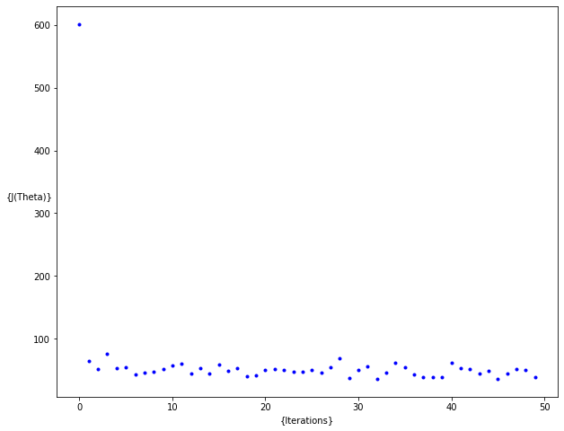

```python
fig,ax = plt.subplots(figsize=(10,8))

ax.set_ylabel('{J(Theta)}',rotation=0)
ax.set_xlabel('{Iterations}')
theta = np.random.randn(2,1)

_=ax.plot(range(n_iter),cost_history,'b.')
```

**La descente de gradient par mini-lots** calcule le gradient sur de petits sous ensembles d’observations sélectionnées aléatoirement qu’on appelle mini-lots.

- Avantage par rapport à la descente de gradient stochastique : amélioration des performances du fait de l’optimisation mat ́erielle des op ́erations matricielles.

```python
#Descente de gradient par mini-lots

def minibatch_gradient_descent(X,y,theta,learning_rate=0.01,iterations=10,batch_size =20):
    m = len(y)
    cost_history = np.zeros(iterations)
    n_batches = int(m/batch_size)

    for it in range(iterations):
        cost =0.0
        indices = np.random.permutation(m)
        X = X[indices]
        y = y[indices]
        for i in range(0,m,batch_size):
            X_i = X[i:i+batch_size]
            y_i = y[i:i+batch_size]

            X_i = np.c_[np.ones(len(X_i)),X_i]

            prediction = np.dot(X_i,theta)

            theta = theta -(1/m)*learning_rate*( X_i.T.dot((prediction - y_i)))
            cost += cal_cost(theta,X_i,y_i)
        cost_history[it]  = cost

    return theta, cost_history
```

```python
lr =0.1
n_iter = 200

theta = np.random.randn(2,1)


theta,cost_history = minibatch_gradient_descent(X,y,theta,lr,n_iter)


print('Theta0:          {:0.3f},\nTheta1:          {:0.3f}'.format(theta[0][0],theta[1][0]))
print('Final cost/MSE:  {:0.3f}'.format(cost_history[-1]))
```

```
Theta0:          4.066,
Theta1:          3.020
Final cost/MSE:  1015.040
```

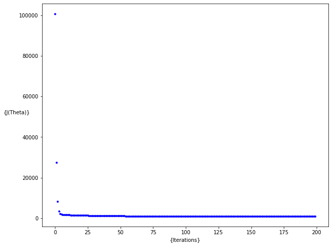

```python
fig,ax = plt.subplots(figsize=(10,8))

ax.set_ylabel('{J(Theta)}',rotation=0)
ax.set_xlabel('{Iterations}')
theta = np.random.randn(2,1)

_=ax.plot(range(n_iter),cost_history,'b.')
```

# **Papa Omar Diop DIC1 GIT**